# MAP: initial variable review

# (I) Exposition

> This report is a record of interaction with a data transfer object (dto) produced by `./manipulation/map/0-ellis-island-map.R`.

The next section recaps this script, exposes the architecture of the DTO, and demonstrates the language of interacting with it.

## (I.A) Ellis Island

> All data land on Ellis Island.

The script `0-ellis-island.R` is the first script in the analytic workflow. It accomplished the following:

- 1. Reads in raw data file
- 2. Extract, combines, and exports metadata (specifically, variable names and labels, if provided) into `./data/shared/meta/map/names-labels-live.csv`, which is updated every time Ellis Island script is executed.
- 3. Augments raw metadata with instructions for renaming and classifying variables. The instructions are provided as manually entered values in `./data/shared/meta/map/meta-data-map.csv`. They are used by automatic scripts in later manipulation and analysis.
- 4. Combines unit and meta data into a single DTO to serve as a starting point to all subsequent analyses.

```r
# load the product of 0-ellis-island.R,  a list object containing data and metadata
# data_path_input  <- "../MAP/data-unshared/derived/ds0.rds" # original
dto <- readRDS("./data-unshared/derived/dto.rds") # local copy
# each element this list is another list:
names(dto)
```

```
[1] "unitData" "metaData"
```

```r
# 3rd element - data set with unit data. Inspect the names of variables:
names(dto[["unitData"]])
```

```
  [1] "id"                    "study"                 "scaled_to"             "agreeableness"
  [5] "conscientiousness"     "neo_altruism"          "neo_conscientiousness" "neo_trust"
  [9] "neuroticism_12"        "openness"              "anxiety_10items"       "neuroticism_6"
 [13] "cogdx"                 "age_bl"                "age_death"             "educ"
 [17] "msex"                  "race"                  "spanish"               "apoe_genotype"
 [21] "alcohol_g_bl"          "alco_life"             "q3smo_bl"              "q4smo_bl"
 [25] "smoking"               "cogact_chd"            "cogact_midage"         "cogact_past"
 [29] "cogact_young"          "lostcons_ever"         "ad_reagan"             "braaksc"
 [33] "ceradsc"               "niareagansc"           "income_40"             "fu_year"
 [37] "scaled_to.y"           "cesdsum"               "r_depres"              "intrusion"
 [41] "neglifeevents"         "negsocexchange"        "nohelp"                "panas"
 [45] "perceivedstress"       "rejection"             "unsympathetic"         "dcfdx"
 [49] "dementia"              "r_stroke"              "cogn_ep"               "cogn_po"
 [53] "cogn_ps"               "cogn_se"               "cogn_wo"               "cogn_global"
 [57] "cts_animals"           "cts_bname"             "catfluency"            "cts_db"
```

[output cut: 21 more lines]

```r
# 4th element - dataset with augmented names and labels of the unit data
knitr::kable(head(dto[["metaData"]]))
```

| name | label | type | name_new | construct | self_reported | longitudinal | unit | include | url | notes |
| --- | --- | --- | --- | --- | --- | --- | --- | --- | --- | --- |
| ad_reagan | Dicotomized NIA-Reagan score | pathology | ad_reagan | alzheimer | FALSE | FALSE | category | NA | https://www.radc.rush.edu/docs/var/detail.htm?category=Pathology&subcategory=Alzheimer%27s%20Disease&variable=niareagansc | NA |
| age_at_visit | Age at cycle - fractional | demographic | age_at_visit | age | FALSE | TRUE | year | TRUE | https://www.radc.rush.edu/docs/var/detail.htm?category=Demographics&variable=age_at_visit | NA |
| age_bl | Age at baseline | demographic | age_bl | age | FALSE | FALSE | year | TRUE | https://www.radc.rush.edu/docs/var/detail.htm?category=Demographics&variable=age_bl | NA |
| age_death | Age at death | demographic | age_death | age | FALSE | FALSE | year | TRUE | https://www.radc.rush.edu/docs/var/detail.htm?category=Demographics&variable=age_death | NA |
| agreeableness | NEO agreeableness-ROS | personality | agreeableness | NA | TRUE | FALSE | scale | NA | NA | NA |
| alcohol_g_bl | Grams of alcohol used per day at baseline | substance | alcohol_g_bl | alcohol | TRUE | FALSE | grams | TRUE | https://www.radc.rush.edu/docs/var/detail.htm?category=Lifestyle&subcategory=Alcohol%20and%20Tobacco%20Use&variable=alcohol_g_bl | NA |

```r
# assing aliases
ds0 <- dto[["unitData"]]
ds <- ds0 # to leave a clean copy of the ds, before any manipulation takes place
```

### Meta

```r
dto[["metaData"]] %>%
  dplyr::select(-url,-notes) %>%
  DT::datatable(
    class   = 'cell-border stripe',
    caption = "This is a dynamic table of the metadata file. Edit at `./data/meta/map/meta-data-map.csv",
    filter  = "top",
    options = list(pageLength = 6, autoWidth = TRUE)
  )
```

|  | name | label | type | name_new | construct | self_reported | longitudinal | unit | include |
| --- | --- | --- | --- | --- | --- | --- | --- | --- | --- |
| 1 | ad_reagan | Dicotomized NIA-Reagan score | pathology | ad_reagan | alzheimer | False | False | category |  |
| 2 | age_at_visit | Age at cycle - fractional | demographic | age_at_visit | age | False | True | year | True |
| 3 | age_bl | Age at baseline | demographic | age_bl | age | False | False | year | True |
| 4 | age_death | Age at death | demographic | age_death | age | False | False | year | True |
| 5 | agreeableness | NEO agreeableness-ROS | personality | agreeableness |  | True | False | scale |  |
| 6 | alcohol_g_bl | Grams of alcohol used per day at baseline | substance | alcohol_g_bl | alcohol | True | False | grams | True |
| 7 | anxiety_10items | Anxiety-10 item version - ROS and MAP | personality | anxiety_10items | anxiety |  | False | scale |  |
| 8 | apoe_genotype | Apolipoprotein E genotype | clinical | apoe_genotype | apoe | False | False | category | True |
| 9 | bmi | Body mass index | physical | bmi | physique | False | True | kg/msq | True |
| 10 | bp11 | Blood pressure measurement- sitting - trial 1 | medical | bp_sit_1 | hypertension | False | True | scale |  |

[output cut: 124 more lines]

# (II) Development

Details were requested about the following items (including the availability of treatment for each) :

1. N at each wave
2. Cognitive capability measures
3. Dementia diagnosis
4. Education
5. Social class
6. Physique
7. Smoking habits
8. Alcohol consumption
9. Social engagement
10. Physical activitiy
11. APOE status
12. Physical capability measures
13. Cardiovascular disease
14. Hypertension
15. Stroke
16. Diabetes

### General comments

for **all variables** conditions, declare whether they are  
- self reported or diagnosed  
- time variant or invariant (study entry only)  
- treatment or management of the conditions is available  
- provide levels and labels for items with categorical responses  
- specific description of measurement encoding

## (1) N at each wave

The following pattern of attrition has been observed in the data

```r
dto[["metaData"]] %>% dplyr::filter(name=="fu_year")
```

```
# A tibble: 1 × 11
     name          label   type name_new construct self_reported longitudinal       unit include   url notes
    <chr>          <chr>  <chr>    <chr>     <chr>         <lgl>        <lgl>      <chr>   <lgl> <chr> <chr>
1 fu_year Follow-up year design  fu_year      time         FALSE         TRUE time point    TRUE  <NA>  <NA>
```

```r
ds %>%
  dplyr::group_by_("fu_year") %>%
  dplyr::summarize(sample_size=n())
```

```
# A tibble: 20 × 2
   fu_year sample_size
     <int>       <int>
1        0        1852
2        1        1613
3        2        1438
4        3        1264
5        4        1095
6        5         908
7        6         787
8        7         644
9        8         524
10       9         439
11      10         348
12      11         290
13      12         200
14      13         130
15      14          52
16      15          33
17      16          19
18      17          17
19      18          19
20      NA           1
```

## (2) Cognitive capability measures

The following measures of cognitive capability are available in the present instance of MAP data:

```r
knitr::kable(dto[["metaData"]] %>%
  dplyr::filter(type=="cognitive") %>%
  dplyr::select(-name,-type,-name_new, -include) %>%
  dplyr::arrange(construct))
```

| label | construct | self_reported | longitudinal | unit | url | notes |
| --- | --- | --- | --- | --- | --- | --- |
| MMSE - 2014 | dementia | TRUE | TRUE | 0 to 30 | NA | NA |
| Dementia diagnosis | dementia | FALSE | TRUE | 0, 1 | NA | NA |
| Calculated domain score-episodic memory | episodic memory | FALSE | TRUE | composite | https://www.radc.rush.edu/docs/var/detail.htm?category=Cognition&subcategory=Domains&variable=cogn_ep | NA |
| Logical memory IIa - 2014 | episodic memory | FALSE | TRUE | 0 to 25 | NA | NA |
| East Boston story - delayed recall - 2014 | episodic memory | FALSE | TRUE | 0 to 12 | NA | NA |
| East Boston story - immediate - 2014 | episodic memory | FALSE | TRUE | 0 to 12 | NA | NA |
| Logical memory Ia - immediate - 2014 | episodic memory | FALSE | TRUE | 0 to 25 | NA | NA |
| Word list I- immediate- 2014 | episodic memory | FALSE | TRUE | 0 to 30 | NA | NA |
| Word list II - delayed - 2014 | episodic memory | FALSE | TRUE | 0 to 10 | NA | NA |
| Word list III - recognition - 2014 | episodic memory | FALSE | TRUE | o to 10 | NA | NA |
| Global cognitive score | global cognition | FALSE | TRUE | composite | https://www.radc.rush.edu/docs/var/detail.htm?category=Cognition&subcategory=Global%20cognition&variable=cogn_global | NA |
| Calculated domain score - perceptual orientation | perceptual orientation | FALSE | TRUE | composite | https://www.radc.rush.edu/docs/var/detail.htm?category=Cognition&subcategory=Domains&variable=cogn_po | NA |
| Line orientation - 2014 | perceptual orientation | FALSE | TRUE | 0 to 15 | NA | NA |
| Progressive Matrices - 2014 | perceptual orientation | FALSE | TRUE | 0 to 16 | NA | NA |
| Calculated domain score - perceptual speed | perceptual speed | FALSE | TRUE | composite | https://www.radc.rush.edu/docs/var/detail.htm?category=Cognition&subcategory=Domains&variable=cogn_ps | NA |
| Number comparison - 2014 | perceptual speed | FALSE | TRUE | 0 to 48 | NA | NA |
| Symbol digit modalitities - 2014 | perceptual speed | FALSE | TRUE | 0 to 110 | NA | NA |
| Calculated domain score - semantic memory | semantic memory | FALSE | TRUE | composite | https://www.radc.rush.edu/docs/var/detail.htm?category=Cognition&subcategory=Domains&variable=cogn_se | NA |
| Boston naming - 2014 | semantic memory | FALSE | TRUE | 0 to 15 | NA | NA |
| Category fluency - 2014 | semantic memory | FALSE | TRUE | 0 to 75 | NA | NA |
| Reading test-NART-2014 | semantic memory | FALSE | TRUE | 0 to 10 | NA | NA |
| Reading test - WRAT - 2014 | semantic memory | FALSE | TRUE | 0 to 15 | NA | NA |
| Complex ideas - 2014 | verbal comprehension | FALSE | TRUE | 0 to 8 | NA | NA |
| Calculated domain score - working memory | working memory | FALSE | TRUE | composite | https://www.radc.rush.edu/docs/var/detail.htm?category=Cognition&subcategory=Domains&variable=cogn_wo | NA |
| Digits backwards - 2014 | working memory | FALSE | TRUE | 0 to 12 | NA | NA |
| Digits forwards - 2014 | working memory | FALSE | TRUE | 0 to 12 | NA | NA |
| Digit ordering - 2014 | working memory | FALSE | TRUE | 0 to 14 | NA | NA |
| Cognitive actifity - child | NA | NA | NA | NA | todo | young adult? |
| Category fluence - Animals | NA | NA | NA | NA | NA | NA |
| Category fluency - Fruits | NA | NA | NA | NA | NA | NA |
| NA | NA | NA | NA | NA | NA | NA |
| NA | NA | NA | NA | NA | NA | NA |
| NA | NA | NA | NA | NA | NA | NA |
| Codnitive activity - middle age | NA | NA | NA | NA | https://www.radc.rush.edu/docs/var/detail.htm?category=Lifestyle&subcategory=Cognitive%20Activity&variable=ma_adult_cogact_freq | NA |
| Cognitive actifity - past | NA | NA | NA | NA | todo | NA |

```r
knitr::kable(dto[["metaData"]] %>%
  dplyr::filter(type=="cognitive", include==TRUE) %>%
  dplyr::select(-type,-name_new, - include) %>%
  dplyr::arrange(construct))
```

| name | label | construct | self_reported | longitudinal | unit | url | notes |
| --- | --- | --- | --- | --- | --- | --- | --- |
| cts_mmse30 | MMSE - 2014 | dementia | TRUE | TRUE | 0 to 30 | NA | NA |
| dementia | Dementia diagnosis | dementia | FALSE | TRUE | 0, 1 | NA | NA |
| cogn_ep | Calculated domain score-episodic memory | episodic memory | FALSE | TRUE | composite | https://www.radc.rush.edu/docs/var/detail.htm?category=Cognition&subcategory=Domains&variable=cogn_ep | NA |
| cogn_global | Global cognitive score | global cognition | FALSE | TRUE | composite | https://www.radc.rush.edu/docs/var/detail.htm?category=Cognition&subcategory=Global%20cognition&variable=cogn_global | NA |
| cogn_po | Calculated domain score - perceptual orientation | perceptual orientation | FALSE | TRUE | composite | https://www.radc.rush.edu/docs/var/detail.htm?category=Cognition&subcategory=Domains&variable=cogn_po | NA |
| cogn_ps | Calculated domain score - perceptual speed | perceptual speed | FALSE | TRUE | composite | https://www.radc.rush.edu/docs/var/detail.htm?category=Cognition&subcategory=Domains&variable=cogn_ps | NA |
| cogn_se | Calculated domain score - semantic memory | semantic memory | FALSE | TRUE | composite | https://www.radc.rush.edu/docs/var/detail.htm?category=Cognition&subcategory=Domains&variable=cogn_se | NA |
| cogn_wo | Calculated domain score - working memory | working memory | FALSE | TRUE | composite | https://www.radc.rush.edu/docs/var/detail.htm?category=Cognition&subcategory=Domains&variable=cogn_wo | NA |
| chd_cogact_freq | Cognitive actifity - child | NA | NA | NA | NA | todo | young adult? |
| ma_adult_cogact_freq | Codnitive activity - middle age | NA | NA | NA | NA | https://www.radc.rush.edu/docs/var/detail.htm?category=Lifestyle&subcategory=Cognitive%20Activity&variable=ma_adult_cogact_freq | NA |
| past_cogact_freq | Cognitive actifity - past | NA | NA | NA | NA | todo | NA |

```r
dto[["unitData"]] %>%
  dplyr::select(id,fu_year, cogn_global) %>%
  dplyr::filter(!is.na(cogn_global)) %>%
  dplyr::group_by(fu_year) %>%
  dplyr::summarize(average_global_cognition = round(mean(cogn_global),3),
                   sd = sprintf("%0.2f",sd(cogn_global)),
                   observed =n())
```

[output not shown]

### Global

Global cognitive score

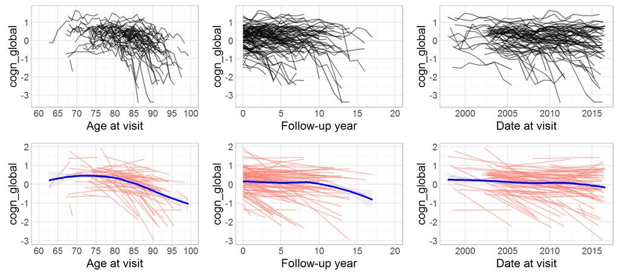

### Semantic

Calculated domain score - semantic memory

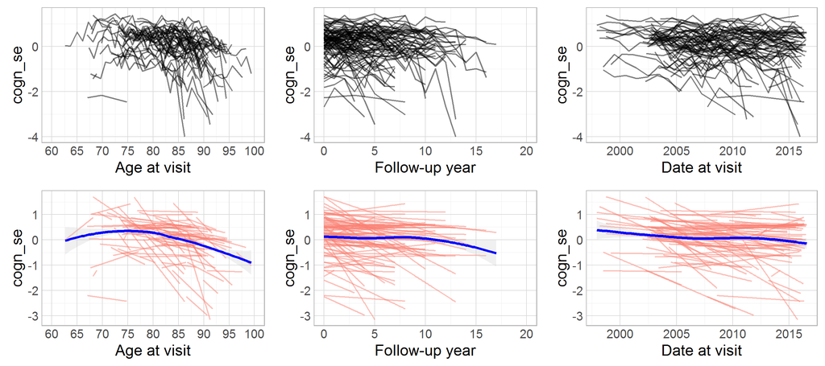

### Episodic

Calculated domain score - episodic memory

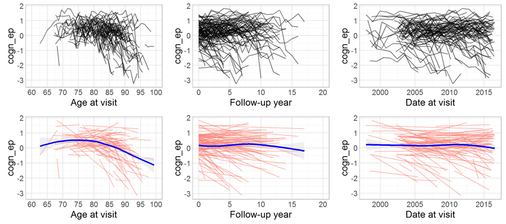

### Working

Calculated domain score - working memory

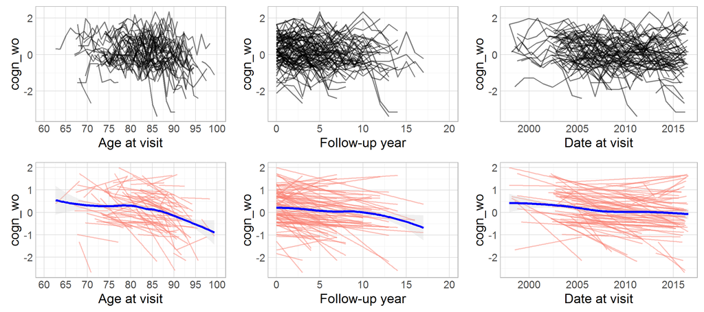

### Perceptual

Calculated domain score - perceptual orientation

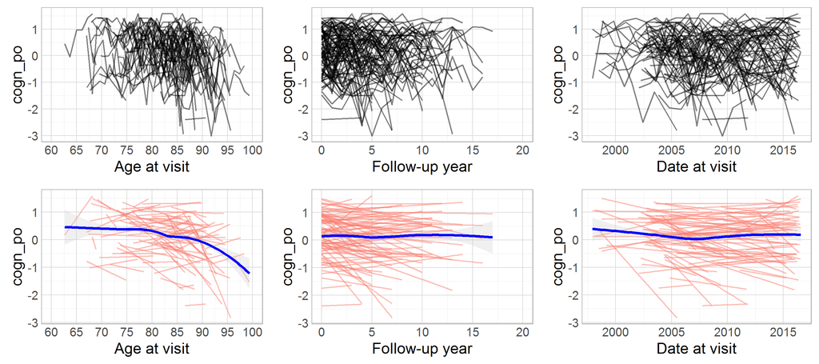

### Speed

Calculated domain score - perceptual speed

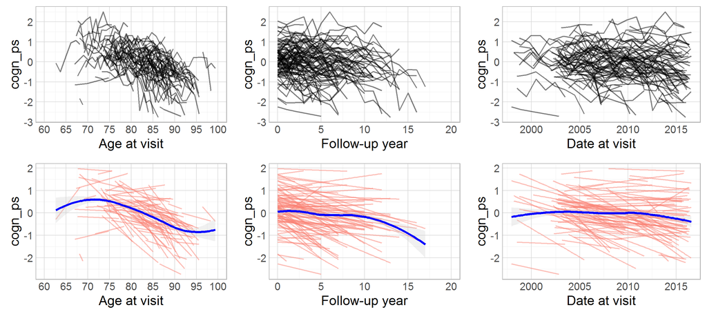

### MMSE

Mini mental state exam

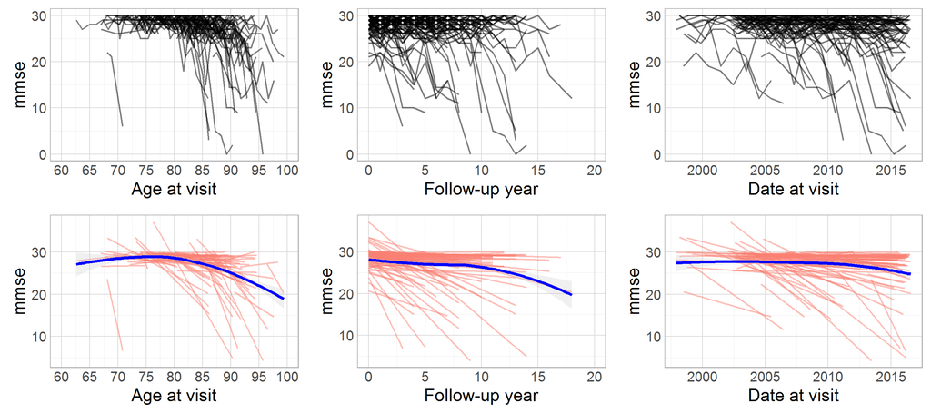

## (3) Dementia

Dementia diagnosis

```
# A tibble: 1 × 11
      name              label      type name_new construct self_reported longitudinal  unit include   url notes
     <chr>              <chr>     <chr>    <chr>     <chr>         <lgl>        <lgl> <chr>   <lgl> <chr> <chr>
1 dementia Dementia diagnosis cognitive dementia  dementia         FALSE         TRUE  0, 1    TRUE  <NA>  <NA>
```

```
# A tibble: 19 × 3
   fu_year percent_diagnosed observed_n
     <int>             <dbl>      <int>
1        0        0.05402485       1851
2        1        0.06721623       1577
3        2        0.09567682       1411
4        3        0.10985460       1238
5        4        0.12298959       1057
6        5        0.13528749        887
7        6        0.13984169        758
8        7        0.17656501        623
9        8        0.18737673        507
10       9        0.17590361        415
11      10        0.17910448        335
12      11        0.20895522        268
13      12        0.21621622        185
14      13        0.24074074        108
15      14        0.25581395         43
16      15        0.26923077         26
17      16        0.36842105         19
18      17        0.33333333         15
19      18        0.40000000          5
```

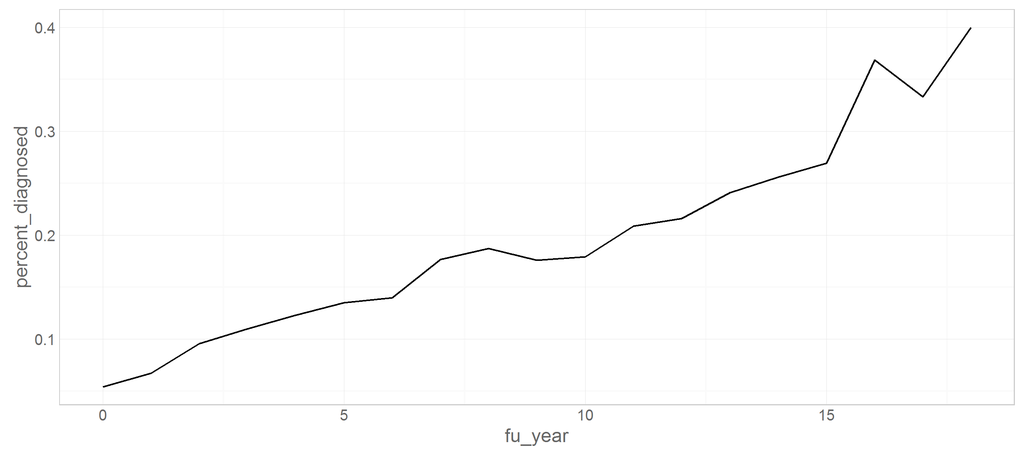

```
# A tibble: 10 × 3
       age_cat percent_diagnosed observed_n
        <fctr>             <dbl>      <int>
1  (53.3,58.8]       0.000000000         32
2  (58.8,64.2]       0.007936508        126
3  (64.2,69.7]       0.021825397        504
4  (69.7,75.2]       0.037790698       1032
5  (75.2,80.6]       0.049713193       2092
6  (80.6,86.1]       0.087291795       3242
7  (86.1,91.5]       0.169130285       2909
8    (91.5,97]       0.262975779       1156
9     (97,102]       0.385650224        223
10   (102,108]       0.416666667         12
```

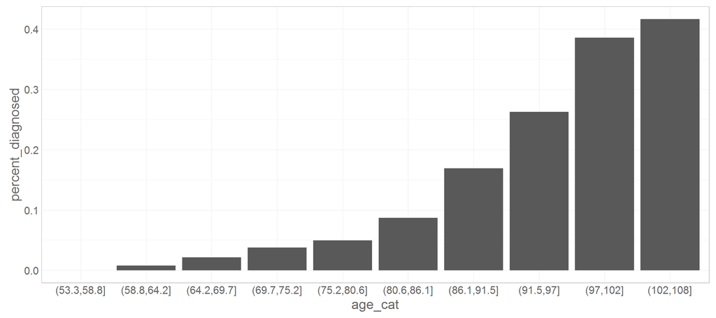

## (4) Education

```
# A tibble: 1 × 11
   name              label        type name_new construct self_reported longitudinal  unit include   url notes
  <chr>              <chr>       <chr>    <chr>     <chr>         <lgl>        <lgl> <chr>   <lgl> <chr> <chr>
1  educ Years of education demographic     educ education          TRUE        FALSE years    TRUE  <NA>  <NA>
```

```
# A tibble: 20 × 4
   fu_year average_years_edu       SD observed_n
     <int>             <dbl>    <dbl>      <int>
1        0          14.61135 3.283566       1850
2        1          14.72226 3.212063       1613
3        2          14.73713 3.193879       1438
4        3          14.74525 3.149982       1264
5        4          14.72785 3.117870       1095
6        5          14.72357 3.167436        908
7        6          14.64676 3.257756        787
8        7          14.75311 3.155322        644
9        8          14.79771 3.114316        524
10       9          14.77221 2.980615        439
11      10          14.81897 2.990665        348
12      11          14.92069 2.945395        290
13      12          14.88000 2.956230        200
14      13          15.00000 3.090370        130
15      14          15.40385 2.802377         52
16      15          14.93939 2.703463         33
17      16          15.31579 2.286497         19
18      17          15.29412 2.084607         17
19      18          14.26316 2.232142         19
20      NA          12.00000      NaN          1
```

## (5) Social class

No indicator of social class if found in our version of MAP data

## (6) BMI

```
# A tibble: 3 × 11
   name           label     type name_new construct self_reported longitudinal   unit include
  <chr>           <chr>    <chr>    <chr>     <chr>         <lgl>        <lgl>  <chr>   <lgl>
1   bmi Body mass index physical      bmi  physique         FALSE         TRUE kg/msq    TRUE
2   htm  Height(meters) physical      htm  physique         FALSE         TRUE meters    TRUE
3  wtkg     Weight (kg) physical     wtkg  physique         FALSE         TRUE  kilos    TRUE
# ... with 2 more variables: url <chr>, notes <chr>
```

```
# A tibble: 19 × 4
   fu_year average_bmi       SD observed_n
     <int>       <dbl>    <dbl>      <int>
1        0    27.27109 5.425121       1799
2        1    27.32047 5.303549       1523
3        2    27.22470 5.295299       1336
4        3    27.17220 5.344430       1148
5        4    27.10899 5.109127        962
6        5    27.09338 5.421648        780
7        6    26.61708 5.317700        629
8        7    26.82205 5.305770        520
9        8    26.83554 5.326082        391
10       9    26.90696 5.710673        346
11      10    27.22139 5.671200        268
12      11    27.18993 5.407083        228
13      12    26.60319 5.336092        152
14      13    27.06171 5.329555         88
15      14    26.89846 5.281620         40
16      15    26.30766 6.085734         20
17      16    28.43710 6.292571         14
18      17    25.51479 2.846066          9
19      18    26.79843 2.434091          6
```